# 请选择你的英雄 —— 王者荣耀英雄职业相关数据探索性分析

## 准备工作

```r
#载入包
library(ggplot2)
library(dplyr)
library(tidyverse)
library(wesanderson)
```

[figure not shown]

## 1. 背景介绍

近年来国内手游呈现“井喷式”发展，以腾讯、网易云、畅游等为代表的游戏公司研发、推出了各式各样的手机游戏，其中，以腾讯推出的MOBA（多人在线战术竞技游戏）手游王者荣耀最具代表性，其产生的影响力也最为广泛而深刻。王者荣耀自2015年11月26日公测至今，打破了性别、年龄、职业、地域等界限，玩家数量超6亿，最高日活跃用户达到过1亿，平均日活跃用户超过5000万。**王者荣耀是目前MOBA类游戏的领头军，多项数据创手游界新高，热议指数高居不下，已经融入了许多玩家的生活**。

**王者荣耀作为最受欢迎的手游之一，其赛事也备受关注**。据弗若斯特沙利文报告，作为《王者荣耀》官方最高规格的专业竞技赛事KPL在2020年总决赛的观众高达1.05亿，远超当年NBA总决赛观众（750万）与英超联赛（1270万）。此外KPL赛事观看量也高达数百亿，官方数据显示，2020年王者荣耀赛事内容总观看量超过730亿，对比2020年初公布的440亿，提升了66%。2023年KPL王者荣耀职业联赛春季赛总决赛开始前，其高价门票先一步冲上热搜，但门票开售后却仍迅速售罄，展现出王者荣耀作为国内顶级游戏IP的市场吸引力。

**除了联赛带来的商业价值，王者荣耀更直接的收入来源是玩家的游戏充值**。日前，外媒根据AppMagic数据整理出2023年度手游收入榜。整体来看，王者荣耀以14.8亿美元再次蝉联全球iOS和Android手游收入榜冠军宝座，且比排名第二的PUBG Mobile高出3亿美元。而用户对于英雄皮肤的消费是其重要的收入来源之一。仅在2021春节，王者荣耀皮肤销售额超3亿，堪称中国互联网普及以来的现象级消费。

虽然王者荣耀已经是国民手游，但每年还是用户数量都在上升，仍然不断有新的玩家加入召唤师的行列。作为的新的玩家，尤其是游戏小白，难免需要花一些功夫了解游戏的规则。除了一些基本的游戏设定外，最重要也最令人纠结的应该就是如何选择自己的英雄了。而选择英雄首先要做的就是决定你偏好的游戏职业。本文研究围绕英雄的游戏职业展开，首先从最基本的英雄初始属性出发，带你了解各个职业的基本特征；然后，结合赛事数据，满足好奇心的同时，向你揭示职业选手和新手小白选择职业和英雄的不同考量；最后，根据英雄皮肤数据，让你提前了解以后的潜在消费。

因此本文的研究问题为：

1. 初始属性分析：各英雄职业有怎样的属性特征？
2. 英雄赛事热度分析：什么职业的英雄比较容易成为赛场明星？为什么？
3. 英雄皮肤价格分析：什么职业的英雄皮肤价格比较高？这和赛事热度有关吗？

为了帮助更好的理解相关分析，下面先简单介绍一下王者荣耀的游戏规则：在王者荣耀中，两支由五名英雄组成的队伍将在地图上展开激烈对抗，当一方成功摧毁敌方基地时，即可获得胜利。在开始比赛前，每位玩家需要选择一个英雄来进行游戏。不同英雄拥有不同技能和特点，在比赛中起着各种作用。英雄一共有六种职业，法师、射手、坦克、战士和辅助。不同类型的英雄适用于不同的阵容，而每一种不同类型的英雄在阵容中所担任的位置也有所不同。合理选择和配合英雄是取得胜利的关键。

## 2. 数据说明

### 2.1 王者英雄初始属性值

此数据集源自[和鲸社区（HeyWhale）](https://www.heywhale.com/home)，作者为“灰海豚fnpk”，上传时间为2021年8月。数据集包含92个英雄的25个初始属性值，包括各个英雄的生存能力、攻击伤害、技能效果、上手难度等等。由于初始属性太多，并且其中有一部分属性在大多数英雄之间取值变化并不明显，因此本文将删除部分初始属性，只保留有区分度和意义的属性，使数据更加简洁便于后续分析工作。最终，本文选取用于分析的属性共9个，数据示例如下：

```r
# 数据读取
hero_attr <- read.csv("all_hero_init_attr.csv", header = T, stringsAsFactors = T, fileEncoding = "GBK")
# 删除部分数据列，只保留本文需要的部分
hero_attr <- hero_attr[, c(1:7, 10, 14, 23)]
#将“攻击范围”转变为哑变量，便于进行分析，近程为0，远程为1
hero_attr$攻击范围 <- as.integer(as.factor(hero_attr$攻击范围)) - 1
# 数据展示
head(hero_attr)
```

A data.frame: 6 × 10

|  | 英雄名字 <fct> | 生存能力 <int> | 攻击伤害 <int> | 技能效果 <int> | 上手难度 <int> | 最大生命 <int> | 最大法力 <int> | 物理防御 <int> | 移速 <int> | 攻击范围 <dbl> |
| --- | --- | --- | --- | --- | --- | --- | --- | --- | --- | --- |
| 1 | 盘古 | 10 | 8 | 8 | 6 | 3067 | 0 | 99 | 380 | 0 |
| 2 | 猪八戒 | 10 | 8 | 10 | 6 | 3067 | 0 | 99 | 380 | 0 |
| 3 | 嫦娥 | 10 | 10 | 10 | 5 | 1600 | 440 | 79 | 395 | 1 |
| 4 | 瑶 | 10 | 7 | 8 | 5 | 3010 | 440 | 87 | 360 | 1 |
| 5 | 上官婉儿 | 5 | 7 | 8 | 6 | 3215 | 440 | 79 | 396 | 1 |
| 6 | 沈梦溪 | 6 | 8 | 10 | 6 | 3238 | 440 | 87 | 396 | 1 |

由于该数据集还缺少英雄职业这一重要属性，因此本文结合官网资料自行统计了这92名英雄对应的职业。将两个数据集对应合并如下：

```r
# 加载readxl包
library(readxl)
# 数据读取
hero_job <- read_excel("hero_job.xlsx")
# 匹配英雄职业
hero_attr = left_join(hero_job, hero_attr, by = c("英雄名字" = "英雄名字"))
# 将职业信息由字符型列转换为因子型数据
hero_attr$游戏职业 <- as.factor(hero_attr$游戏职业)
# 数据展示
head(hero_attr)
```

A tibble: 6 × 11

| 英雄名字 <chr> | 游戏职业 <fct> | 生存能力 <int> | 攻击伤害 <int> | 技能效果 <int> | 上手难度 <int> | 最大生命 <int> | 最大法力 <int> | 物理防御 <int> | 移速 <int> | 攻击范围 <dbl> |
| --- | --- | --- | --- | --- | --- | --- | --- | --- | --- | --- |
| 阿轲 | 刺客 | 2 | 10 | 4 | 6 | 3269 | 0 | 89 | 380 | 0 |
| 艾琳 | 射手 | 3 | 6 | 8 | 6 | 3182 | 440 | 86 | 350 | 1 |
| 安琪拉 | 法师 | 5 | 9 | 8 | 6 | 3323 | 490 | 83 | 360 | 1 |
| 白起 | 坦克 | 9 | 4 | 4 | 3 | 3510 | 420 | 120 | 390 | 0 |
| 百里守约 | 射手 | 3 | 6 | 8 | 6 | 3182 | 440 | 86 | 350 | 1 |
| 百里玄策 | 刺客 | 5 | 8 | 8 | 10 | 3359 | 450 | 88 | 380 | 0 |

各王者英雄初始属性变量的介绍与说明如下：

[figure not shown]

### 2.2 王者荣耀赛事数据

此数据来源为[王者荣耀官方赛事数据平台](https://datamore.qq.com/project/wzmatch/dist/index.html#/)下载。为匹配英雄初始属性和英雄皮肤数据的取得时间，在网站选取2021年8月近一年的全部赛事数据.该数据集共包括102个有效样本，以及除英雄名称外Pick场数、总击杀、胜率、出场率、热度等13个变量的数据。本文主要关心热度这一结合了出场率、胜率和Ban率的综合性指标，将该指标与英雄初始属性对应合并，得到88个有效观测。

```r
# 数据读取
competition_data <- read_excel("全部英雄赛事数据20200801-20210801.xlsx")
# 匹配英雄职业
hero_pop = left_join(competition_data[, c(1, ncol(competition_data))], hero_attr, by = c("英雄" = "英雄名字"))
# 将职业信息由字符型列转换为因子型数据
hero_pop$游戏职业 <- as.factor(hero_pop$游戏职业)
# 删除带有缺失值的行
hero_pop <- na.omit(hero_pop)
# 数据展示
head(hero_pop)
```

A tibble: 6 × 12

| 英雄 <chr> | 热度 <dbl> | 游戏职业 <fct> | 生存能力 <int> | 攻击伤害 <int> | 技能效果 <int> | 上手难度 <int> | 最大生命 <int> | 最大法力 <int> | 物理防御 <int> | 移速 <int> | 攻击范围 <dbl> |
| --- | --- | --- | --- | --- | --- | --- | --- | --- | --- | --- | --- |
| 盾山 | 0.74 | 辅助 | 10 | 5 | 10 | 5 | 3041 | 125 | 79 | 530 | 0 |
| 猪八戒 | 0.64 | 坦克 | 10 | 8 | 10 | 6 | 3067 | 0 | 99 | 380 | 0 |
| 公孙离 | 0.62 | 射手 | 3 | 5 | 8 | 8 | 3041 | 200 | 91 | 350 | 1 |
| 不知火舞 | 0.59 | 法师 | 3 | 5 | 9 | 9 | 3235 | 200 | 89 | 390 | 0 |
| 大乔 | 0.57 | 辅助 | 3 | 3 | 6 | 8 | 2958 | 470 | 93 | 360 | 1 |
| 马可波罗 | 0.55 | 射手 | 7 | 5 | 6 | 6 | 3041 | 200 | 91 | 350 | 1 |

### 2.3 王者荣耀英雄皮肤数据

此数据集源自[和鲸社区（HeyWhale）](https://www.heywhale.com/home)，作者为“Python研究者”。数据集于2021年8月上传，包含2017年3月8日至2021年8月13日王者荣耀推出的英雄皮肤信息，共190个样本量，以及对应英雄、皮肤名称、所需点券（虚拟货币价格，1元人民币=10点券）、类型、上线时间、宣传口号，六个变量。将英雄热度、职业与该数据进行匹配，删除有缺失值的观测后，还剩余166个有效观测。数据示例如下：

```r
# 数据读取
hero_skins <- read.csv("hero_skins.csv", header = T, stringsAsFactors = T, fileEncoding = "UTF-8")
# 匹配英雄职业
hero_skins = left_join(hero_skins, hero_pop[, 1:3], by = c("英雄" = "英雄"))
# 删除带有缺失值的行
hero_skins <- na.omit(hero_skins)
# 数据展示
head(hero_skins)
```

A data.frame: 6 × 8

|  | 英雄 <chr> | 皮肤 <fct> | 点券 <fct> | 类型 <fct> | 上线时间 <int> | 口号 <fct> | 热度 <dbl> | 游戏职业 <fct> |
| --- | --- | --- | --- | --- | --- | --- | --- | --- |
| 1 | 王昭君 | 乞巧织情 | 1688 | 限定 | 20210813 | 荣耀中国节系列七夕乞巧节皮肤 | 0.12 | 法师 |
| 3 | 鲁班七号 | 乒乒小将 | 888 | 限定 | 20210716 | 国民记忆乒乓球主题皮肤，致敬国乒，传承荣耀 | 0.13 | 射手 |
| 4 | 杨戬 | 天秀·启明 | 888 | 史诗 | 20210723 | 全民电竞首款皮肤，普通人的电竞梦想 | 0.01 | 战士 |
| 6 | 大乔 | 白鹤梁神女 | 888 | 限定 | 20210703 | 重庆白鹤梁博物馆合作皮肤 | 0.57 | 辅助 |
| 7 | 伽罗 | 天狼溯光者 | 888 | KPL限定 | 20210626 | 天狼星小队集结！ | 0.27 | 射手 |
| 8 | 老夫子 | 航海奇遇记 | 388 | 战令限定 | 20210623 | 战令限定，奇妙的航海冒险 | 0.10 | 战士 |

注：虽然采用的数据不是最新数据，但是考虑到三份数据的时间较为接近，数据集涉及的英雄（88/117）也涵盖了大部分英雄。同时，现在与三年前相比英雄的属性相对值变化很小。因此，本文认为采用以上数据进行分析仍具有实际意义。

## 3. 数据分析

### 3.1 英雄初始属性分析——从属性了解英雄职业

#### 3.1.1 英雄初始属性相关性

如图，展示了英雄初始属性之间的相关系数图。从图中较为明显的几对负相关关系，可以发现**英雄初始属性是“鱼和熊掌不可兼得”的**，关于防御、生存的属性往往和进攻属性呈负相关。例如，攻击范围和生存能力、最大生命、物理防御、移速呈负相关的关系，因为远程攻击本身已经增加了攻击范围、降低了被伤害的概率，如果再加上快速移动那么短时间内英雄能够实现的攻击范围将再次被扩大，如果血条和生存能力也很高那么英雄还会更难在游戏中死亡。**这样相对无敌的英雄在王者荣耀中是不太允许存在的，正是因为每个英雄都各有所长各有所短，所以英雄各有职业分工，需要搭档与配合、团结与协作，而团队作战也是王者荣耀的最具魅力的地方之一。也正是因为没有完美的英雄，所以每一个英雄都有了存在的意义，在自己的天地闪烁着耀眼的光芒。**

类似的图中还可以看到物理防御和攻击伤害呈负相关、移速和最大法力呈负相关、最大生命和技能效果呈负相关。而防御属性和进攻属性的内部存在一些正相关关系，例如生存能力这一综合指标与物理防御和移速呈正相关、物理防御和最大生命呈正相关、最大法力和攻击范围正相关。

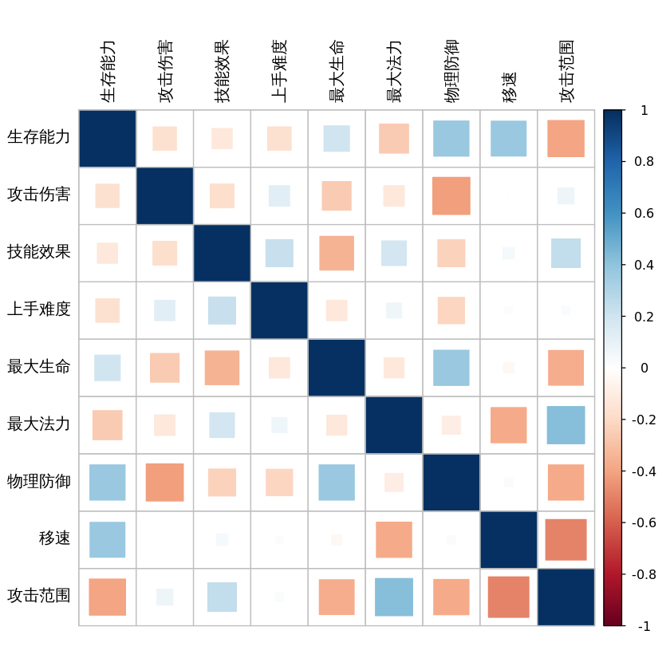

```r
# 使用par()函数设置参数，指定中文字体
par(family = "STKaiti")
#画相关系数图
library(corrplot)
corrplot(cor(hero_attr[, -c(1, 2), drop = FALSE]), tl.col = "black", method = 'square')
```

#### 3.1.2 不同职业的英雄的属性特征

#### （1）存活与防御属性

**1）对抗路英雄坦克和战士的较高防御属性**

由下图可以看到**坦克和战士在与防御、存活有关的属性方面都是位于前三名的**。对抗路前期与敌人的碰撞较多主要任务是守护己方防御塔，同时尽量击败敌方英雄；后期在团战中，对抗路英雄需要控制对方英雄，担任前排抗伤，保护后排队友输出。坦克英雄由于通常拥有高生命值和强大的抗性能力，能够承受敌方的伤害，并在战斗中保护队友，是对抗路的首选英雄之一。而战士英雄具有持续战斗能力和输出的爆发伤害，防御性也较高，团战时，可以吸收敌方英雄的伤害，又可以造成一定量的伤害。因此，战士英雄也是对抗路常见的选择之一。

**2）输出伤害型英雄法师和射手的“脆皮”属性**

**法师和射手与坦克和战士相反，在与防御、存活有关的属性方面都是位于后三名的**。法师和射手输出伤害高，相应的生命值和防御就低、属于脆皮类英雄，在团战中容易被敌方英雄集火先秒杀，或偷袭秒杀。在团战时，法师和射手站位以后排为主，需要己方英雄给予保护。

**3）刺客以偷袭为主，自身防御较低**

刺客的输出方式一般都是突袭，利用突然袭击，使敌人没有过多的反应时间，从而达到输出最大化。因此，**刺客整体移速最高**。此外，**刺客也具有低防御的特点，生存能力较低**。刺客为了提高自己所能造成的伤害，会致力与暴力和伤害之间，因此忽略了防御和生命线。这也是刺客致命的弱点，一旦被提前围杀或者控制，那么就面临必死的命运。

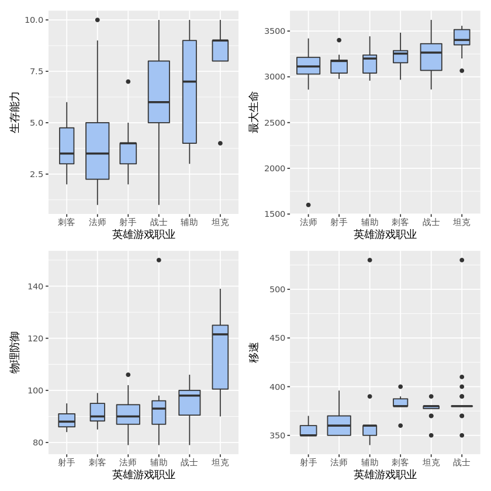

```r
# 绘制不同职业的英雄的生存能力箱线图
plot1 <- ggplot(data = hero_attr) +
  geom_boxplot(mapping = aes(x = reorder(游戏职业, 生存能力, median, decreasing = T),
                             y = 生存能力), varwidth = TRUE, fill = "#A3C4F3")+
  theme(text = element_text(family = "STKaiti"))+
  labs(x="英雄游戏职业", y="生存能力")

# 绘制不同职业的英雄的最大生命箱线图
plot2 <- ggplot(data = hero_attr) +
  geom_boxplot(mapping = aes(x = reorder(游戏职业, 最大生命, median, decreasing = T),
                             y = 最大生命), varwidth = TRUE, fill = "#A3C4F3")+
  theme(text = element_text(family = "STKaiti"))+
  labs(x="英雄游戏职业", y="最大生命")

# 绘制不同职业的英雄的物理防御箱线图
plot3 <- ggplot(data = hero_attr) +
  geom_boxplot(mapping = aes(x = reorder(游戏职业, 物理防御, median, decreasing = T),
                             y = 物理防御), varwidth = TRUE, fill = "#A3C4F3")+
  theme(text = element_text(family = "STKaiti"))+
  labs(x="英雄游戏职业", y="物理防御")

# 绘制不同职业的英雄的移速箱线图
plot4 <- ggplot(data = hero_attr) +
  geom_boxplot(mapping = aes(x = reorder(游戏职业, 移速, median, decreasing = T),
                             y = 移速), varwidth = TRUE, fill = "#A3C4F3")+
  theme(text = element_text(family = "STKaiti"))+
  labs(x="英雄游戏职业", y="移速")

# 将几幅图画在同一张画布上
library(patchwork)
plot1 + plot2 + plot3 + plot4
```

#### （2）进攻属性

**1）法师和射手不同类型的高输出伤害**

**法师属于魔法伤害型英雄**，主要依靠释放技能造成法术伤害，因此法师技能效果和最大法力平均水平更高，而代表物理真实伤害的攻击伤害基本属于一般水平。**射手英雄多为远程物理输出（普通攻击/平A）为主，因此攻击伤害平均水平最高**，而与魔法伤害相关的技能效果和最大法力属于一般水平。

射手英雄由其名称显而易见全部都是持箭或枪进行远程攻击。而法师也一直是以远距离的魔法伤害秒人所著称的位置，虽然也有露娜这类刺客型法师，但是主流还是远程的法师英雄。法师中为远程攻击的占比也在80%以上。

**2）刺客单体杀伤力强**

**3）坦克和战士近身肉搏型伤害**

坦克和战士大多数主要近程物理攻击，在团战中在前排与敌人近身肉搏，为队友抗伤。这两种英雄近程攻击占比都在80%以上，而总体法力比较低，技能效果和最大法力都属于后两位。二者区别是，战士的物理攻击伤害整体强于坦克。

**4）辅助单体作战能力不强，默默为团队付出**

辅助单体作战能力不强，从图中可以看到**辅助攻击伤害的整体水平最低**。在自身存活和防御方面辅助英雄也没有亮眼表现。但辅助能在前期保护ADC（能够打出最多物理伤害的角色，多指射手位），后期团战抗伤害、为队友提供增益性技能，是一个非常无私的职业。

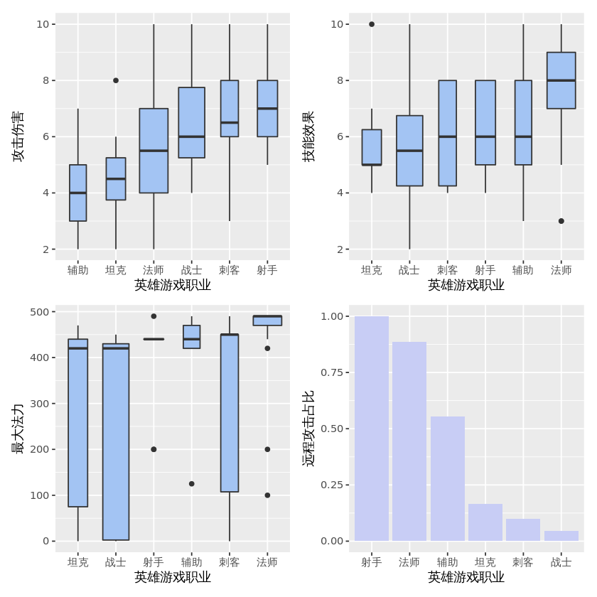

```r
# 绘制不同职业的英雄的攻击伤害箱线图
plot5 <- ggplot(data = hero_attr) +
  geom_boxplot(mapping = aes(x = reorder(游戏职业, 攻击伤害, median, decreasing = T),
                             y = 攻击伤害), varwidth = TRUE, fill = "#A3C4F3")+
  theme(text = element_text(family = "STKaiti"))+
  labs(x="英雄游戏职业", y="攻击伤害")

# 绘制不同职业的英雄的技能效果箱线图
plot6 <- ggplot(data = hero_attr) +
  geom_boxplot(mapping = aes(x = reorder(游戏职业, 技能效果, median, decreasing = T),
                             y = 技能效果), varwidth = TRUE, fill = "#A3C4F3")+
  theme(text = element_text(family = "STKaiti"))+
  labs(x="英雄游戏职业", y="技能效果")

# 绘制不同职业的英雄的最大法力箱线图
plot7 <- ggplot(data = hero_attr) +
  geom_boxplot(mapping = aes(x = reorder(游戏职业, 最大法力, median, decreasing = T),
                             y = 最大法力), varwidth = TRUE, fill = "#A3C4F3")+
  theme(text = element_text(family = "STKaiti"))+
  labs(x="英雄游戏职业", y="最大法力")

# 绘制不同职业的英雄的远程攻击占比柱状图
plot8 <- hero_attr %>%
  group_by(游戏职业) %>%
  summarize(远程攻击占比 = mean(攻击范围)) %>%
  ggplot() +
  geom_bar(mapping = aes(x = reorder(游戏职业, -远程攻击占比), y = 远程攻击占比),
           stat = "identity", fill = "#C8CDF5")+
  theme(text = element_text(family = "STKaiti"))+
  labs(x="英雄游戏职业", y="远程攻击占比")

# 将几幅图画在同一张画布上
plot5 + plot6 + plot7 + plot8
```

#### （3）上手难度

了解了各英雄职业的基本特征，那么作为新手来说哪些职业的英雄相对来说会更容易上手呢？从下图可知，**承担更少输出伤害作用的坦克和辅助上手难度的中位数明显更低**。攻击技能种类繁多、每个英雄的技能释放方式各不相同，并且作用对象是敌人，会躲避和反抗，因此操作难度相对较大。而做肉盾抗伤害和为提供增益性技能，作用对象是队友，操作难度相对较低。而刺客具有较强的单体杀伤力，移动速度一般也较快，生存能力还比较弱，需要看准时机、一击即中，因此上手难度的上限比较高。

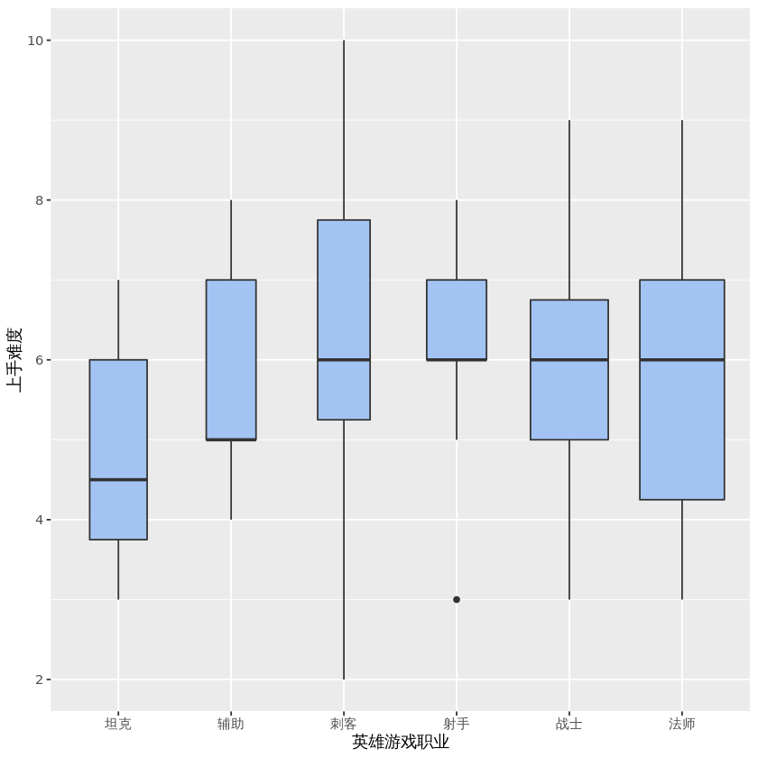

```r
# 绘制不同职业的英雄的上手难度箱线图
ggplot(data = hero_attr) +
  geom_boxplot(mapping = aes(x = reorder(游戏职业, 上手难度, median, decreasing = T),
                             y = 上手难度), varwidth = TRUE, fill = "#A3C4F3")+
  theme(text = element_text(family = "STKaiti"))+
  labs(x="英雄游戏职业", y="上手难度")
```

以上只是对于英雄初始属性的分析，在英雄升级以及技能和装备的加持下，不同职业的属性特点可能会进一步放大。

## 3.2 英雄赛事热度分析

### 3.2.1 王者荣耀英雄赛事热度整体分布

为了更好的理解各职业英雄的热度情况，我们应该先对英雄赛事热度整体分布有一个大概的了解。王者荣耀赛事数据中的英雄热度整体呈现明显的右偏分布，绝大多数英雄的热度集中在[0,0.4)区间，其中热度在[0,0.2)区间的英雄最多，只有很少一部分英雄拥有超高热度，在[0.6,0.8)区间。具体来说，英雄赛事热度中位数为0.09，平均值为0.16，较小四分位数为0.01。说明大部分英雄还是比较默默无闻的，**只有少部分英雄能够榜上有名成为赛场明星**。

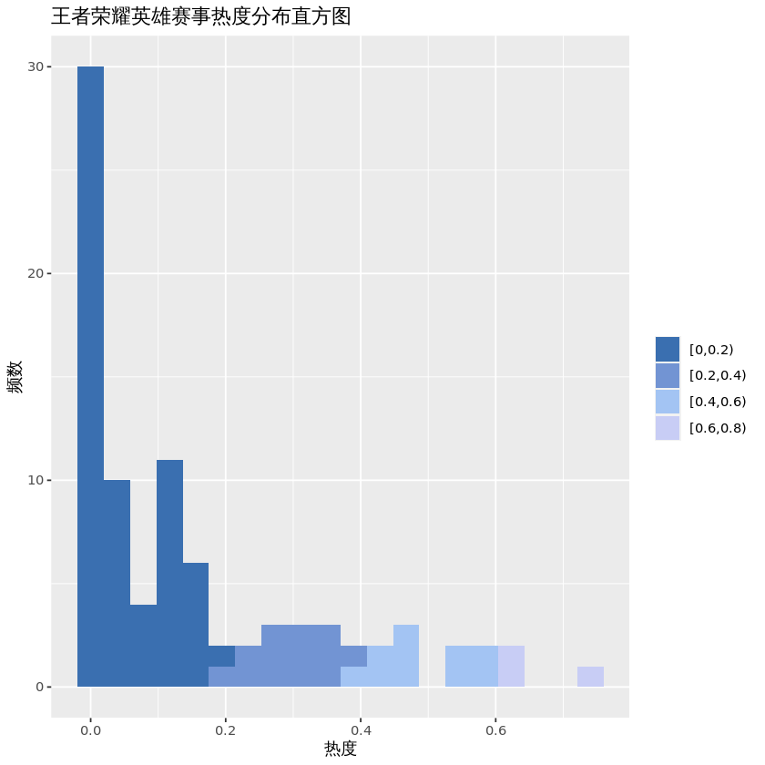

```r
# 绘制直方图
ggplot(data = hero_pop) +
  geom_histogram(mapping = aes(x = 热度, fill = cut(热度, breaks = c(0, 0.2, 0.4, 0.6, 0.8), right = FALSE)), bins = 20) +
  theme(text = element_text(family = "STKaiti")) +
  labs(x = "热度", y = "频数", title = "王者荣耀英雄赛事热度分布直方图", fill = "") +
  scale_fill_manual(values= c("#3A6FB0", "#7294D3", "#A3C4F3", "#C8CDF5"))
```

#### 3.2.2 不同职业英雄的热度分布情况

根据英雄赛事数据得到的英雄热度取值范围是0到0.74，为了方便分析与画图，本文将热度分为0-0.2、0.2-0.4、0.4-0.6、0.6-0.8四个左闭右开区间。统计各游戏职业在每个热度区间的英雄数量，画成棘状图。由图可知，**射手、辅助、坦克三种职业的英雄热度相对更高**。其中，射手英雄中大部分英雄都具有一定热度（0.2及以上），而英雄最少的辅助职业高热度（0.4及以上）英雄占比最大。

一方面，射手和辅助英雄数量不是特别多（尤其是辅助），一定程度上有利于热度的集中。而相反，法师和战士的英雄数量较多就相对不利于热度的集中。另外，射手作为整个团队的输出主力，与法师并称c位，也受到很多人的喜爱。射手这个职业的英雄本来身板又很脆弱，要么就靠着大量的吸血一战超神，要么团战开始前就被灭杀。比赛上更多人希望一举成名，偏好干脆和纯粹的输出，所以像鲁班、后羿这样的老牌射手英雄深得玩家们的喜欢，热度较高。而辅助虽然操作相对简单，门槛也较低，但其实真正达到赛级水平是有很大难度跨度的，在王者高端局中，辅助英雄也发挥着非常重要的作用。同时，个别辅助英雄的特殊技能，例如盾山的挡击技能，能够极大提升整个团队的安全感，因此在赛事数据中也会保持高热度。

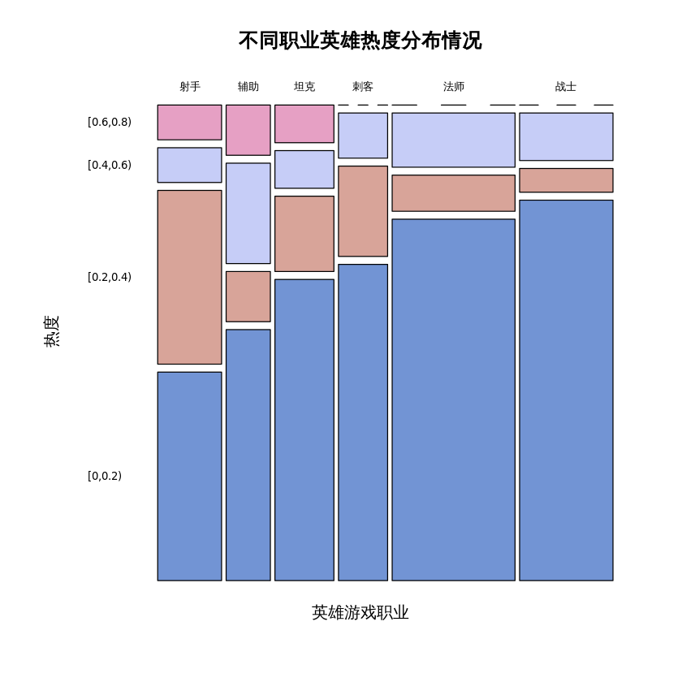

```r
hero_pop$pop.cut = cut(hero_pop$热度, breaks = c(0, 0.2, 0.4, 0.6, 0.8),
                     lables = c("0-0.2", "0.2-0.4", "0.4-0.6", "0.6-0.8"), right = FALSE)
# 生成游戏职业和pop.cut的二维表
count_in_range <- table(hero_pop$游戏职业, hero_pop$pop.cut)
# 列顺序反过来
count_in_range <- count_in_range[, order(colnames(count_in_range), decreasing = TRUE)]
# 获取按照最后一列数据排序后的行索引
sorted_rows <- order(count_in_range[, ncol(count_in_range)]/rowSums(count_in_range), decreasing = FALSE)
# 应用排序后的行索引到表格
count_in_range_sorted <- count_in_range[sorted_rows, ]
# 使用par()函数设置参数，指定中文字体
par(family = "STKaiti")
# 画棘状图
mypalette <- wes_palette("GrandBudapest2", 4, type = "continuous")
mosaicplot(count_in_range_sorted, main = "不同职业英雄热度分布情况",
           xlab = "英雄游戏职业", ylab = "热度",
           col = mypalette, off = 5, las = 1)
```

由于在赛事中出场的英雄其各项属性已经和初始属性相去甚远，因此英雄的对应的职业关键属性的初始值与英雄赛事热度的相关性并不显著，此处不再分析。

### 3.3 英雄皮肤价格分析

#### 3.3.1 英雄皮肤价格分布情况

英雄皮肤大多数需要使用点券（虚拟货币，充值1元人名币可获得10点券）购买，少部分时通过抽奖、夺宝和贵族限定特权获得。数据集中只有一个虞姬的皮肤是需要玩家的贵族等级达到V8（累计充值金额达到5000元）才能够获得，可以说是免费的，也可以说是最贵的。使用点券购买的皮肤价位一共有8种价位，价格跨度从0到1788点券。其中，888点券的皮肤数量最多，可能是因为该价格中等偏高并且数字吉利。中间价位488和660的皮肤数量较少。高价位皮肤（888及以上）整体数量多于免费和低价位皮肤（388及以下）。可以看出，**大部分皮肤的主要消费者定位是具有一定经济能力玩家**。皮肤的推出更多还是旨在吸引消费者充值，为游戏公司创收。

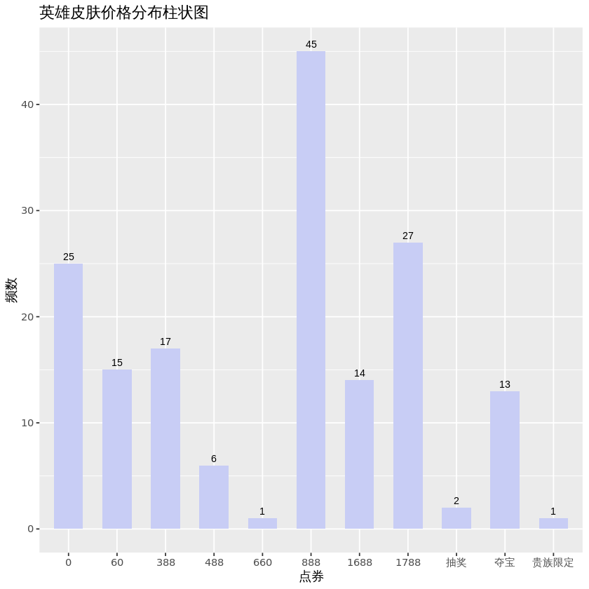

```r
# 创建统计频数的数据框便于画图
freq = table(hero_skins$点券)
freq_dataframe <- as.data.frame(t(freq))
# 绘制柱状图
dianquan_order <- c('0', '60', '388', '488', '660', '888', '1688', '1788', '抽奖', '夺宝', '贵族限定')
ggplot(data = freq_dataframe, aes(x = factor(Var2, levels = dianquan_order), y = Freq)) +
  geom_col(fill = "#C8CDF5", width = 0.6) +
  theme(text = element_text(family = "STKaiti")) +
  geom_text(aes(label = Freq), vjust = -0.5, size = 3) +
  labs(x = "点券", y = "频数", title = "英雄皮肤价格分布柱状图")
```

#### 3.3.2 不同职业英雄的皮肤价格差异

为了便于比较，这里我们不考虑需要通过抽奖、夺宝和贵族限定特权获得的皮肤。并且将价值1788、1688和888点券的皮肤认为是贵价皮肤，将其他皮肤归为平价皮肤。绘制不同职业英雄平价、贵价皮肤占比图和不同职业英雄皮肤平均价格柱状图。从图中可以看出，无论是从贵价皮肤占比的角度，还是平均价格的角度，**射手英雄整体来看皮肤价格都是最高的，而辅助和坦克英雄整体皮肤价格偏低**。

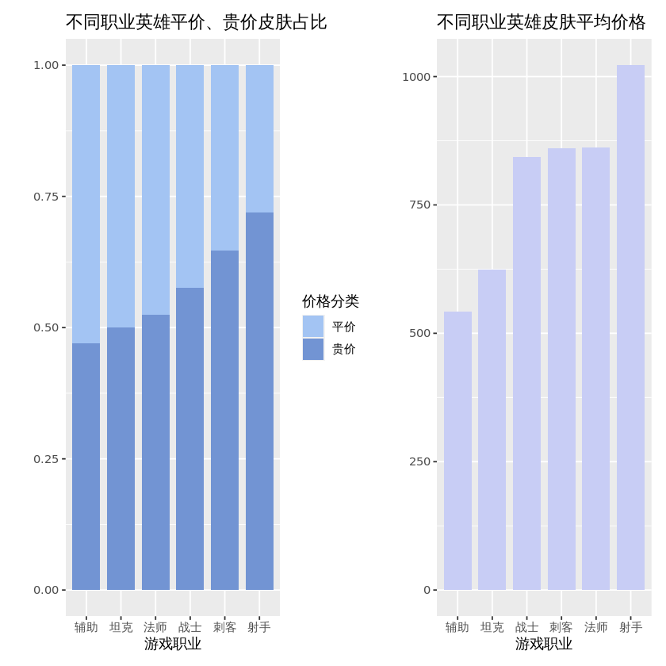

```r
# 生成新数据框，去掉通过抽奖、夺宝和贵族限定特权获得的皮肤
new_hero_skins <- hero_skins[!(hero_skins$点券 %in% c("抽奖", "夺宝", "贵族限定")), ]
# 点券列转换为整数型
new_hero_skins$点券 <- as.integer(as.character(new_hero_skins$点券))
# 生成新变量划分皮肤为平价、贵价两类
new_hero_skins$价格分类 <- ifelse(new_hero_skins$点券 %in% c(1788, 1688, 888), "贵价", "平价")
# 绘制不同职业英雄平价、贵价皮肤占比图
p1 <- ggplot(data = new_hero_skins,
       aes(x = reorder(游戏职业, 价格分类 == '贵价', mean, decreasing = T),
           fill = 价格分类)) +
  geom_bar(position = "fill", width = 0.8) +
  theme(text = element_text(family = "STKaiti")) +
  scale_fill_manual(values= c("#A3C4F3", "#7294D3")) +
  labs(x = "游戏职业", y = "",
       title = "不同职业英雄平价、贵价皮肤占比")

# 绘制不同职业英雄皮肤平均价格柱状图
p2 <- new_hero_skins %>%
  group_by(游戏职业) %>%
  summarise(average_price = mean(点券)) %>%
  ggplot() +
  geom_bar(mapping = aes(x = reorder(游戏职业, average_price, mean, decreasing = T),
                         y = average_price),
           stat = "identity", fill = "#C8CDF5", width = 0.8) +
  theme(text = element_text(family = "STKaiti")) +
  labs(x = "游戏职业", y = "",
       title = "不同职业英雄皮肤平均价格")

# 将两幅图画在一起
p1 + p2
```

#### 3.3.3 不同热度英雄的皮肤价格差异

王者荣耀的赛事向来受到玩家的广泛关注。那么赛场上叱咤风云的英雄是否皮肤价格也更高呢？从下图可以得知赛事中高热度英雄的皮肤不一定有高的定价。热度低于0.4的英雄对应的皮肤整体价格高于热度高于0.4的英雄的皮肤。贵价皮肤占比最高的是热度处于[0.2,0.4)较为中等水平的英雄。**皮肤价格并不完全与英雄热度成正比**的原因可能是赛场热度是对于职业选手的偏好而言的，而不是针对普通玩家的。部分普通玩家由于操作技术等原因，英雄偏好可能与赛场热门相去甚远。因此有些低热度英雄可能背后有众多的普通玩家，皮肤有很大的消费者市场，能够获得较高的溢价。

此外，根据赛事数据热度为[0,0.2)、[0.2,0.4)、[0.4,0.6)和[0.6,0.8)的英雄占比分别约为70.5%、14.8%、11.4%和3.4%。在英雄皮肤数据中，皮肤对应英雄的热度为[0,0.2)、[0.2,0.4)、[0.4,0.6)和[0.6,0.8)的比例分别约为70%、16%、10.7%和3.3%。二者比例基本保持不变，也**证明在推出英雄皮肤时并没有“厚此薄彼”**。赛场热度高或低的英雄都会有皮肤装扮。

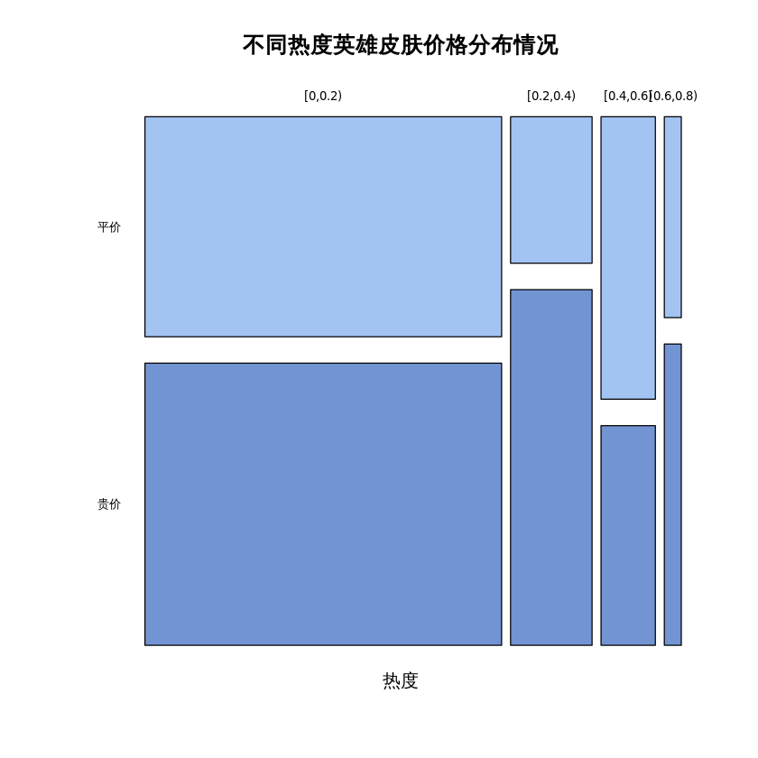

```r
# 匹配合并热度分段数据
new_hero_skins = left_join(new_hero_skins, hero_pop[, c(1, 13)], by = c("英雄" = "英雄"))
# 生成pop.cut和价格分类的二维表
freq_table <- table(new_hero_skins$pop.cut, new_hero_skins$价格分类)
# 使用par()函数设置参数，指定中文字体
par(family = "STKaiti")
# 画棘状图
mosaicplot(freq_table, main = "不同热度英雄皮肤价格分布情况",
           xlab = "热度", ylab = "",
           col = c("#A3C4F3", "#7294D3"), off = 5, las = 1)
```

## 4. 总结

英雄初始属性是“鱼和熊掌不可兼得”的，没有完美、无敌的英雄存在。这一点也体现在游戏职业特点的设置上。对抗路英雄坦克和战士的较高防御属性，但是整体来看攻击伤害不强。因此，在团战中，对抗路英雄需要控制对方英雄，担任前排抗伤，保护后排队友输出。法师和射手分别具备高输出伤害的法力攻击和物理攻击，但是生命值和防御就低、属于脆皮类英雄，在团战中容易被敌方英雄集火先秒杀，或偷袭秒杀。在团战时，法师和射手站位以后排为主，需要己方英雄给予保护。刺客有着很强单体杀伤力和很快的移速，以偷袭为主，自身防御较低。辅助单体作战能力不强，主要是为队友提供增益性技能，帮助整个团队走向胜利。

从平均水平来说，坦克和辅助上手难度较低，刺客上手难度的上限比较高。而根据赛事数据，射手、辅助、坦克三种职业的英雄热度相对更高。其中，射手英雄中大部分英雄都具有一定热度（0.2及以上），而英雄最少的辅助职业高热度（0.4及以上）英雄占比最大。上手难度较低的坦克和辅助，入门与真正达到赛级水平还是有很大难度跨度的，其赛场热度体现出职业选手和新手小白选择职业和英雄的考量有较大差异。

英雄的皮肤价格方面，射手英雄整体来看皮肤价格都是最高的，而辅助和坦克英雄整体皮肤价格偏低。皮肤价格与英雄的赛场热度没有正相关关系，英雄皮肤的推出并没有“厚此薄彼”。

综上，新手玩家可以根据自身性格和喜好，结合游戏职业的特点选择对应的英雄。例如，如果你比较喜欢幕后奉献，善于沟通、协作，可以选择尝试玩辅助位。另外，新手玩家应该认识到一个英雄成为赛场明星的原因是很复杂的，并不一定意味着该英雄是版本之子，更不一定就合适所有人。因此，不要盲目追逐赛场热门英雄。最后，辅助和坦克英雄平价皮肤可能会更多，如有必要也可纳入英雄选择的考虑。皮肤购买应量力而行。